# Visualization of scRNA-seq data

Pang Wei Koh

5/19/2016

We first load in the data, filtering out all genes that don’t have at least 10 TPM in at least 20 cells.

```r
library(ggplot2)
library(dplyr)
library(assertthat)
library(reshape2)

source('analysis.r')
source('metadata.r')
scExperimentMetadata <- getScExperimentMetadata()
celltypesToExclude <- getCelltypesToExclude()
celltypesToCompare <- getCelltypesToCompare()

minTPM <- 10
minCellsWithMinTPM <- 20
scTPMData <- read.csv('sc_tpm.csv', header = TRUE)
scTPMData <- scTPMData[, 3:ncol(scTPMData)] # Remove geneSymbol and geneID columns

idxToKeep <- which(rowSums(scTPMData >= minTPM) >= minCellsWithMinTPM)
scTPMData <- scTPMData[idxToKeep, ]
logScTPM <- log2(scTPMData + 1)
```

Then, we use the top 500 genes by variance to make a PCA plot of the data. The data separates by cell type, which is expected; we note that this is perfectly confounded with batch, in the sense that each cell type was loaded onto a different Fluidgm C1 chip. Cell types that are closer to each other biologically (and temporally) tend to cluster more closely together.

```r
numTopGenes <- 500
idxOfTop <- order(apply(logScTPM, 1, var), decreasing = TRUE)[1:numTopGenes]

topTPM <- logScTPM[idxOfTop, ]
pca <- PCA(t(topTPM), scExperimentMetadata, PCs=c(1,2), intgroup=c('Celltype'))
```

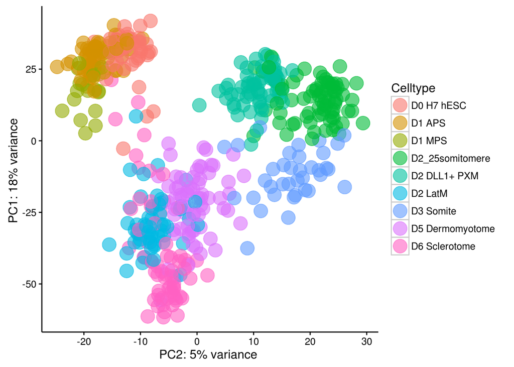

As a sanity check, we verify that the TPM values are roughly log-normal in distribution, after removing zeros (which tend to be inflated because of a dropout effect).

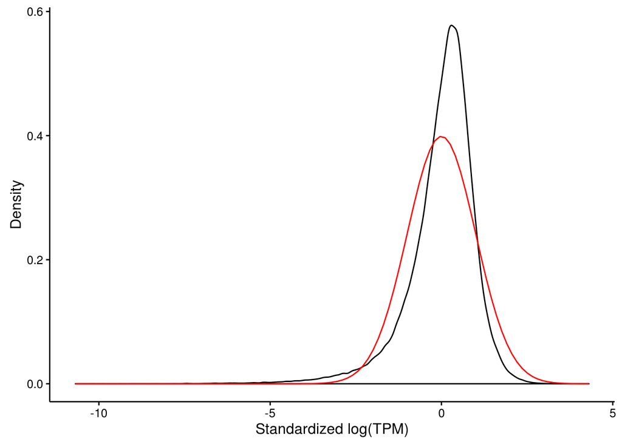

```r
densityDf <- melt((scale(t(log2(scTPMData)))))

ggplot(densityDf, aes(value)) +
  geom_density() +
  theme_bw() +
  theme(panel.border = element_blank(), panel.grid.major = element_blank(),
        panel.grid.minor = element_blank(), axis.line = element_line(colour = "black")) +
  stat_function(fun = dnorm, size = 0.5, color = "red") +
  xlab("Standardized log(TPM)") +
  ylab("Density")
```

Lastly, for each cell type, we plot the standard deviation of the expression of each gene against its average expression value.

```
## [1] "D0 H7 hESC"
```

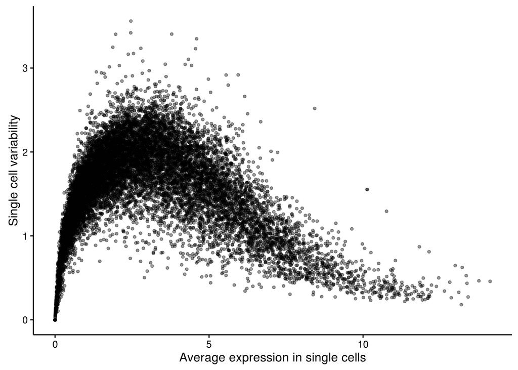

```
## [1] "D1 APS"
```

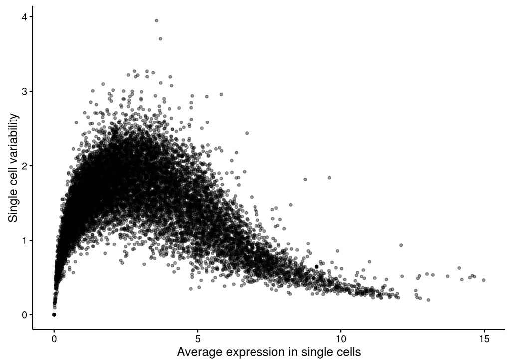

```
## [1] "D1 MPS"
```

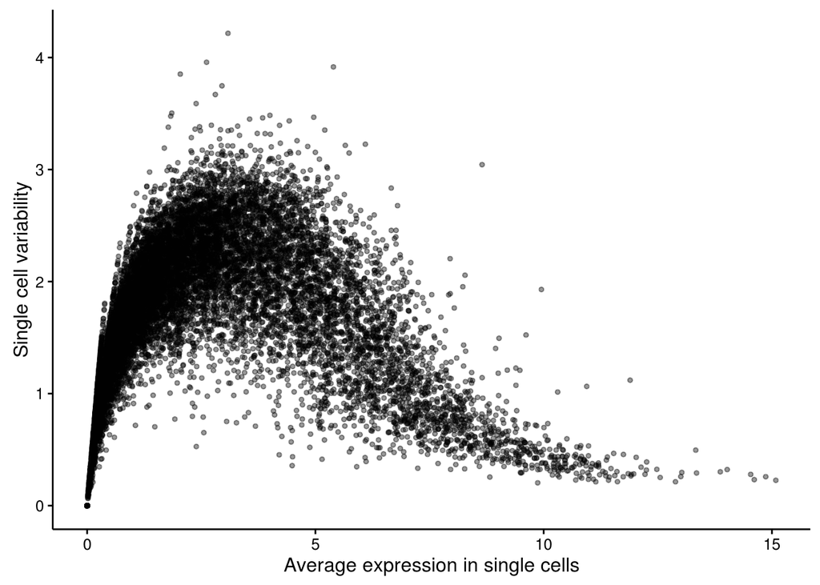

```
## [1] "D2 DLL1+ PXM"
```

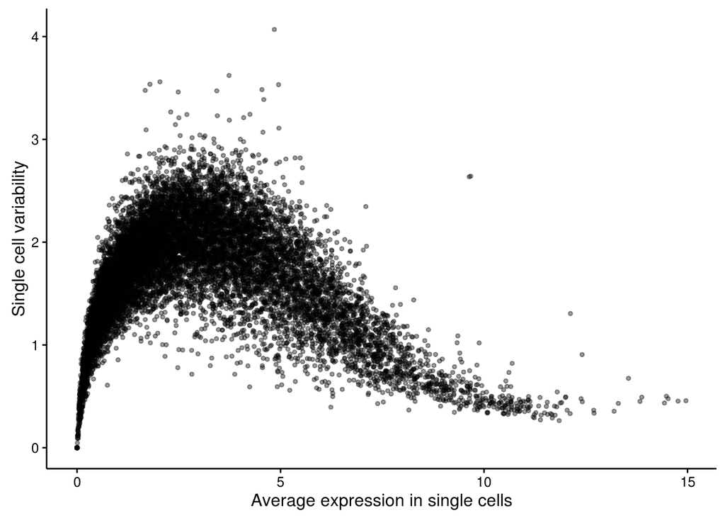

```
## [1] "D3 Somite"
```

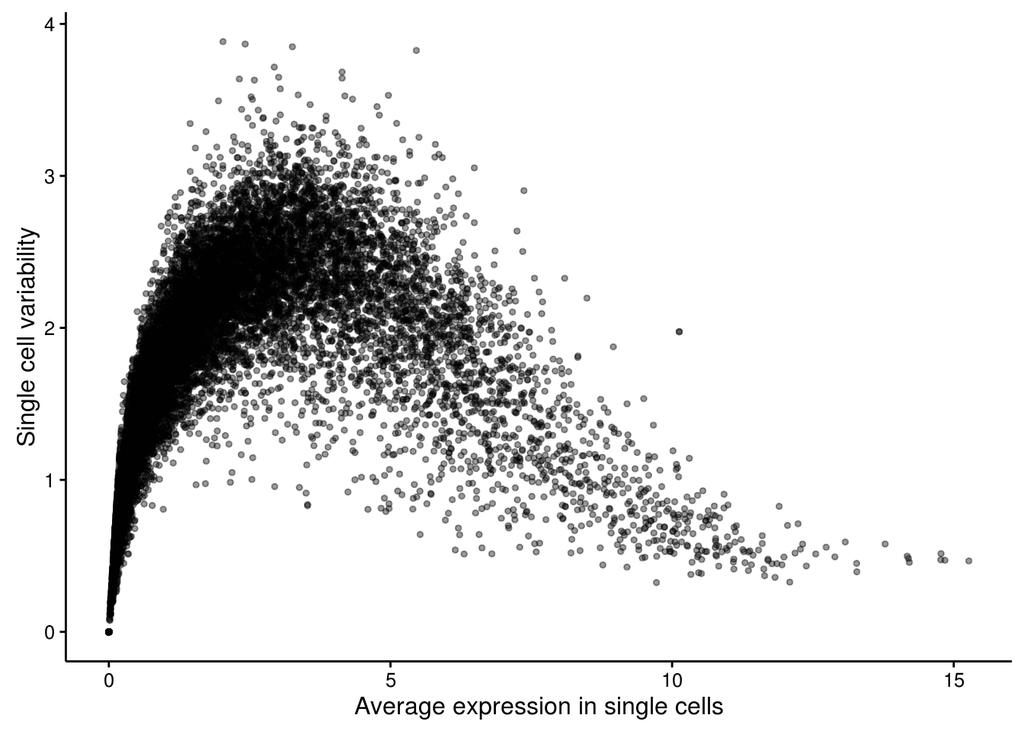

```
## [1] "D5 Dermomyotome"
```

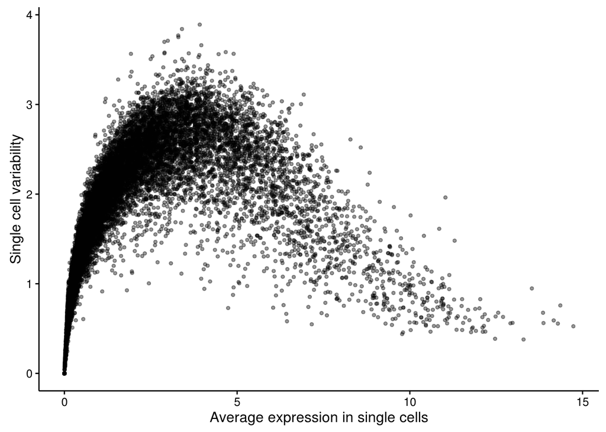

```
## [1] "D6 Sclerotome"
```

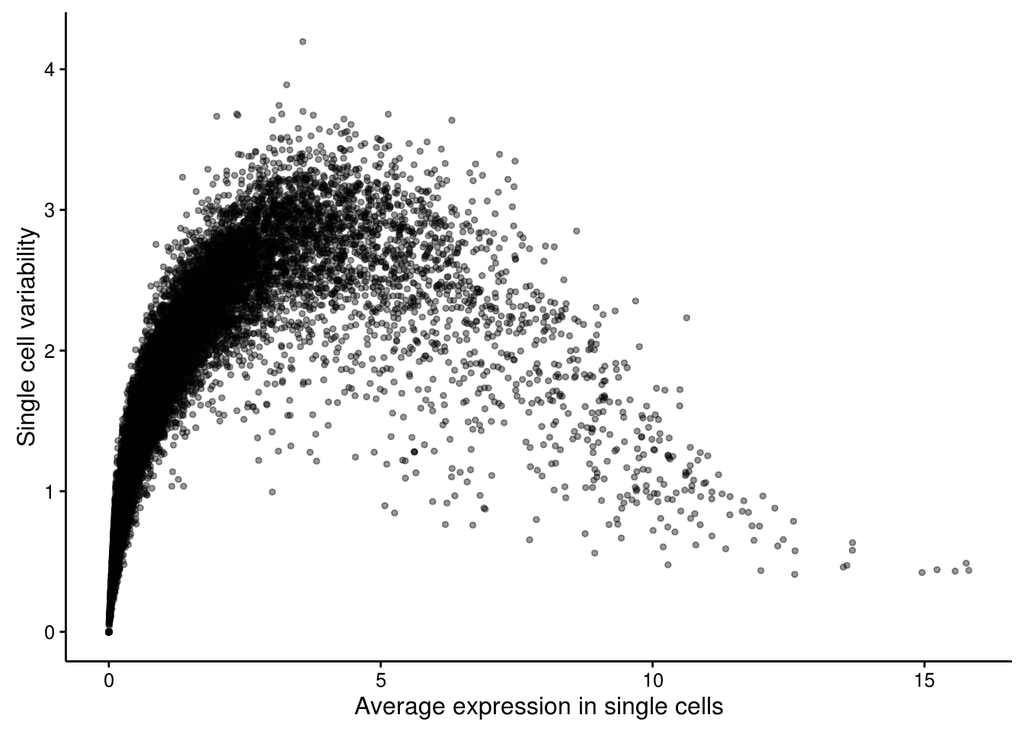

```r
for (celltype in c('D0 H7 hESC', 'D1 APS', 'D1 MPS', 'D2 DLL1+ PXM', 'D3 Somite', 'D5 Dermomyotome', 'D6 Sclerotome')){

  scIdxOfCelltype = (scExperimentMetadata$Celltype == celltype)
  logScTPMCelltype = logScTPM[, scIdxOfCelltype]

  statsToPlot = data.frame(
    m = rowMeans(logScTPMCelltype),
    stdev = apply(logScTPMCelltype, 1, sd))

  p <- ggplot(statsToPlot, aes_string(x = "m", y = "stdev")) +
    geom_point(size = 1, alpha = 0.40) +
    theme(text = element_text(size=15)) +
    theme_bw() +
    theme(panel.border = element_blank(), panel.grid.major = element_blank(),
          panel.grid.minor = element_blank(), axis.line = element_line(colour = "black")) +
    xlab("Average expression in single cells") +
    ylab("Single cell variability")

  print(celltype)
  print(p)
}
```